# Trip Sequencing Part 3

Dave Hurst

Monday, February 16, 2015

Continuing the work to convert a trip into a sequence of segments. The input will be a full trip, and the output will be broken up into several components: - A list of segments with details (or reference to details) on each segment - A sequence of segment ID’s that comprise the trip - A of set data for each segment type

I’m going to try to reconstruct each trip out of segments made up of the following types:

- stops *DONE: See part 1* (no driver profile for these, but we need them to describe the segment)
- sharp turns *DONE: See part 2*
- curves (differentiated from sharp turns by radii (as a function of speed))
- bends ( differentiated from curves by time < 3 data points)
- straights
- uncategorized:  
  – short straights (too short to collect profile info)  
  – slow rolling sections (drive thrus, driveways, etc. – no profile info)  
  – windy sections (ideally break these up later)  
  – other?

## Exploration

Same usual setup, same driver/trip 2591/49

```r
trip.seg <- segment.by.stops(trip)
trip.seg <- segment.by.turns( trip, trip.seg)
```

`trip.seg` is now where we left it in part 2.

```r
segs <- trip.seg[!grepl("^x", trip.seg$type), ]
segs <- segs[ order(segs$t0),]
segs
```

```
##    id  t0  tn type type.id
## 16 16   1  16 <NA>      NA
## 17 17  17  19 turn    2001
## 18 18  20  31 <NA>      NA
## 3   3  32  38 stop       1
## 19 19  39 108 <NA>      NA
## 20 20 109 111 turn    4001
## 5   5 113 130 stop       2
## 22 22 131 172 <NA>      NA
## 23 23 173 175 turn    6001
## 24 24 176 199 <NA>      NA
## 25 25 200 203 turn    6002
## 7   7 205 313 stop       3
## 9   9 315 324 stop       4
## 28 28 326 328 turn   10001
## 29 29 329 352 <NA>      NA
## 11 11 353 362 stop       5
## 30 30 363 407 <NA>      NA
## 31 31 408 411 turn   12001
## 32 32 412 488 <NA>      NA
## 33 33 489 491 turn   12002
## 35 35 493 494 turn   12003
## 36 36 495 504 <NA>      NA
## 37 37 505 509 turn   12004
## 38 38 510 542 <NA>      NA
## 39 39 543 547 turn   12005
## 40 40 548 558 <NA>      NA
## 13 13 559 595 stop       6
## 14 14 596 598 <NA>      NA
## 15 15 599 611 stop       7
```

Starting with a visual inspections of segment t=39:108 to come up with some rules

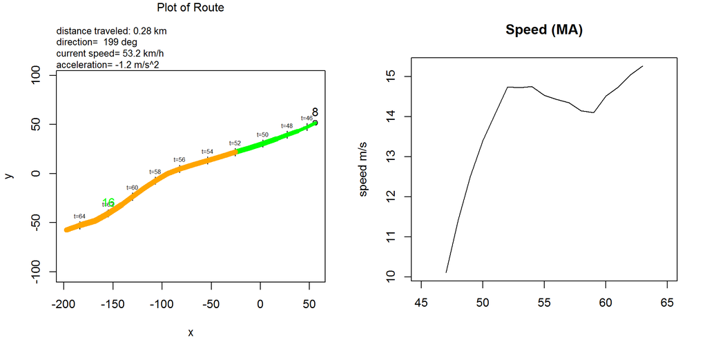

```r
#plotTripSegment(trip, 39, 108, t.mark=5)
plotTripSegment(trip, 45, 65, t.mark=2)
```

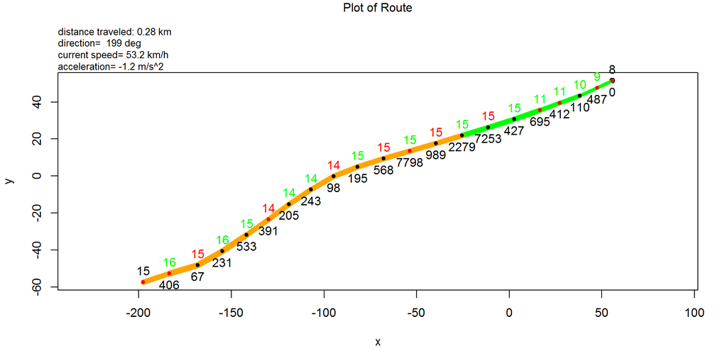

```r
plotTrip.r(trip,  tmin=45, tmax=65)
```

- r < 200
- constant direction of curve – and back off/add a point – for the example (originally) plotted here I want the curve to be defined by the sequence with R values (568,195,98,243). The next “curve” is a bend because it only drops below 200 for one point (R=67) and then switches curvature

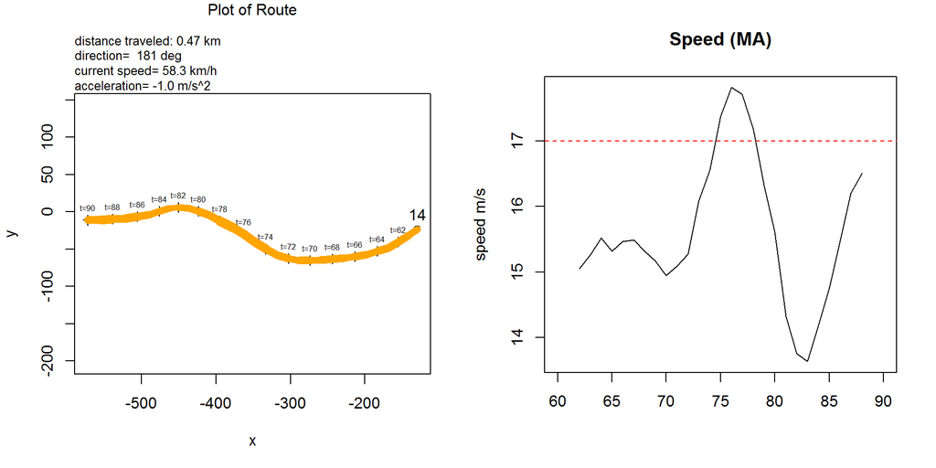

```r
#plotTripSegment(trip, 39, 108, t.mark=5)
plotTripSegment(trip, 60, 90, t.mark=2)
```

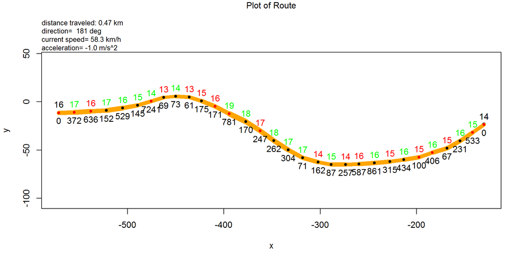

```r
plotTrip.r(trip,  tmin=60, tmax=90)
```

Continuing with the rules above, we get a curve defined for R values – 257,87,162,71,304 (right hand) – 171, 175,61,73,69 (left hand) — note: the backoff 1 doesn’t work for the last one, since the curve changes direction

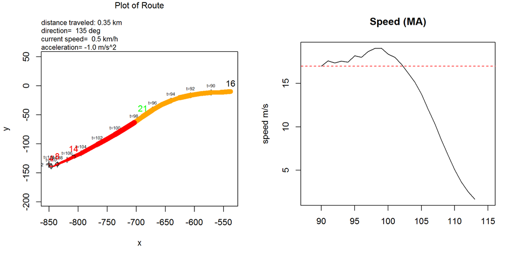

```r
#plotTripSegment(trip, 39, 108, t.mark=5)
plotTripSegment(trip, 88, 115, t.mark=2)
```

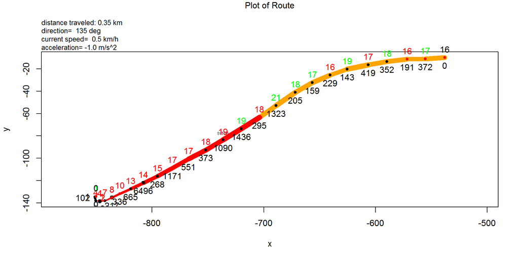

```r
plotTrip.r(trip,  tmin=88, tmax=115)
```

This is a gradual curve in laymans turns, but a series of bends in mine (up to now). So I think I’m getting wrapped around the axle with trying to capture both driving behavior (i.e. its a curve if it affects their speed) and geography. Because the behavior needs to account for connected segments … i.e. driving behavior in an S-curve probably differs for a curve of identical radius connected by straights. So for now I’m just going to try and capture the geographical curves. I’ll start by just capturing sequences of similar radius and lets arbitrarily say at least 4 points less than r=1000

I’ve implemented that using segment.by.curve.gen, and re-written segment.by.turn to use that function as well. Here are the curve segments it finds for this trip.

```r
#trip.seg <- segment.by.stops(trip)
#trip.seg <- segment.by.turns( trip, trip.seg)
trip.seg <- segment.by.curve.gen( trip, trip.seg, r.thresh=1000, t.thresh=4, ctype="curve")
segs <- trip.seg[!grepl("^x", trip.seg$type), ]
segs <- segs[ order(segs$t0),]
curves <- segs[grepl("curve",segs$type), ]
curves
```

```
##    id  t0  tn  type type.id
## 42 42   4   7 curve   16001
## 45 45  55  59 curve   19001
## 47 47  65  75 curve   19002
## 49 49  79  83 curve   19003
## 51 51  91  96 curve   19004
## 54 54 177 185 curve   24001
## 57 57 332 337 curve   29001
## 59 59 339 346 curve   29002
## 62 62 364 367 curve   30001
## 65 65 426 434 curve   32001
## 67 67 436 439 curve   32002
## 69 69 441 448 curve   32003
## 71 71 454 468 curve   32004
## 73 73 470 474 curve   32005
## 75 75 476 479 curve   32006
## 78 78 522 525 curve   38001
## 80 80 527 532 curve   38002
```

```r
turns <- segs[grepl("turn",segs$type), ]
stops <- segs[grepl("stop",segs$type), ]
```

I wrote plotTripOverlay to handle overlays of segments which should help view the data. Since this trip doubles back on itself, I’ve plotted it in two parts. The curved sections are blue, and the sharp turns are magenta. Stops are marked with the numbered diamonds.

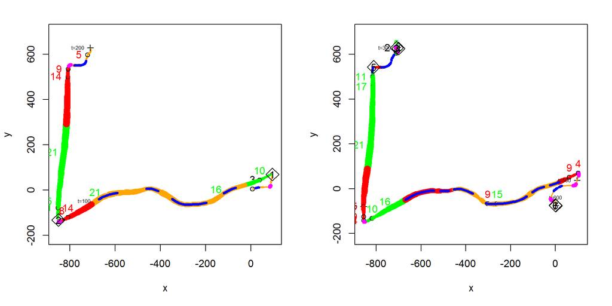

```r
   par.orig <- par(mfrow=c(1,2))
plotTrip       (trip,         tmax=200, header=F)
plotTripOverlay(trip, curves, tmax=200)
plotTripOverlay(trip, turns, tmax=200, lwd=6, col="magenta")
plotTrip.stopOverlay(trip, stops, tmax=200)

plotTrip       (trip,         tmin=200, header=F)
plotTripOverlay(trip, curves, tmin=200)
plotTripOverlay(trip, turns, tmin=200, lwd=6, col="magenta")
plotTrip.stopOverlay(trip, stops, tmin=200)
```

```r
   par(par.orig)
```

Let’s examine the discrepancies between the outgoing and return trips:

- the first stop in the outgoing trip prevents the turnout from being considered a turn. Since the driver doesn’t stop at that location on the return trip it is a turn
- the same thing happens in reverse for the location at stop 5
- there is a double curve prior to stop 5 on the return trip that doesn’t show up on the outgoing … need to investigate that
- a curve-straightish-curve section just prior to t100 is 3 curves on the return
- plus a few other discrepancies in the bend, but overall not too shabby.

We’ll look a little closer at the start/end sections of the trip:

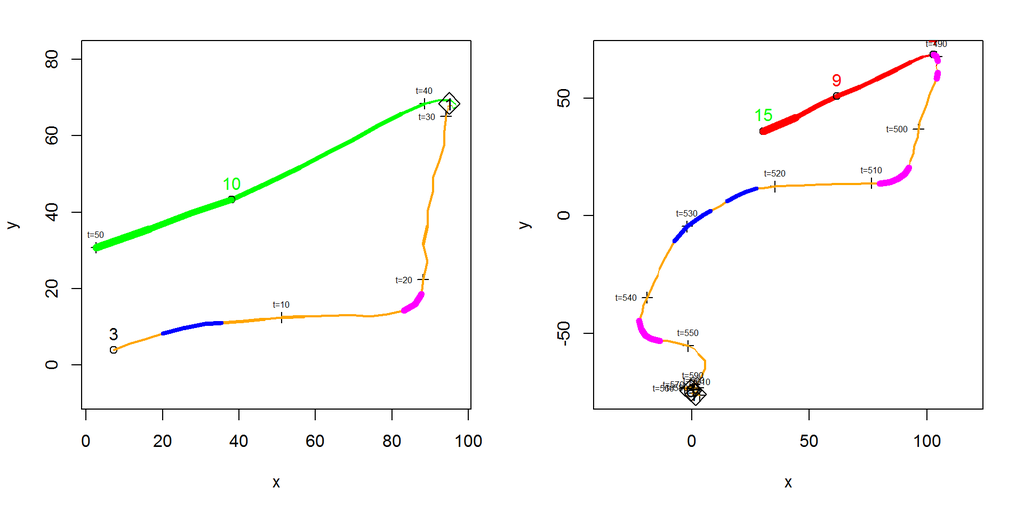

```r
   par(mfrow=c(1,2))
t1 <- 50
t2 <- 480
plotTrip       (trip,         tmax=t1, header=F, t.mark=10)
plotTripOverlay(trip, curves, tmax=t1)
plotTripOverlay(trip, turns, tmax=t1, lwd=6, col="magenta")
plotTrip.stopOverlay(trip, stops, tmax=t1)

plotTrip       (trip,         tmin=t2, header=F, t.mark=10)
plotTripOverlay(trip, curves, tmin=t2)
plotTripOverlay(trip, turns, tmin=t2, lwd=6, col="magenta")
plotTrip.stopOverlay(trip, stops, tmin=t2)
```

```r
   par(par.orig)
```

I’m surprised that there are 2 turns at 490 … the second one doesn’t look right. Taking a closer look, the turn is only two points (raise the t.thresh ?) and speed is below 3 m/s (set another threshold) … live with this one for now,

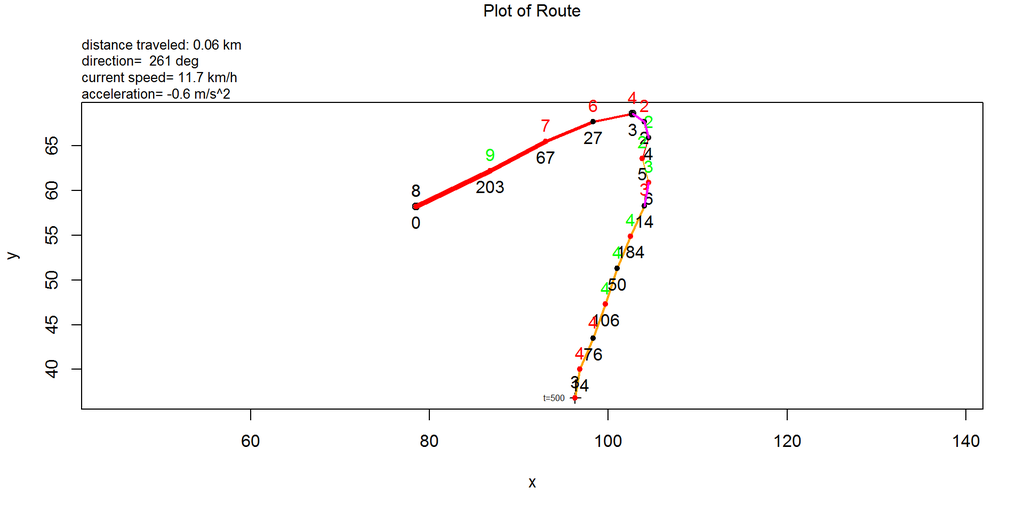

```r
plotTrip.r (trip, tmin=485, tmax=500)
plotTripOverlay(trip, turns, tmin=485, lwd=2, col="magenta")
```

Looking at the other ends (actually the middle):

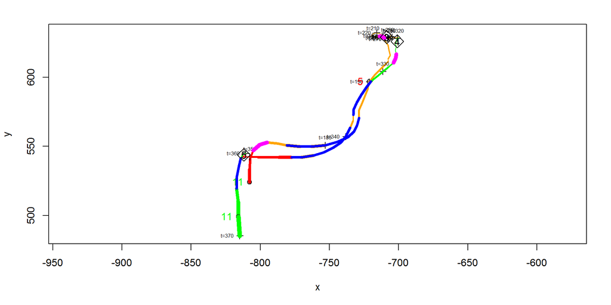

```r
   par(mfrow=c(1,1))
t1.0 <- 170; t1.n <- 370
#t2.0 <- 300; t2.n <- 370
plotTrip       (trip,  tmin=t1.0, tmax=t1.n, header=F, t.mark=10)
plotTripOverlay(trip, curves, tmin=t1.0, tmax=t1.n)
plotTripOverlay(trip, turns, tmin=t1.0, tmax=t1.n, lwd=6, col="magenta")
plotTrip.stopOverlay(trip, stops, tmin=t1.0, tmax=t1.n)
```

```r
# plotTrip       (trip, tmin=t2.0, tmax=t2.n, header=F, t.mark=10)
# plotTripOverlay(trip, curves, tmin=t2.0, tmax=t2.n)
# plotTripOverlay(trip, turns, tmin=t2.0, tmax=t2.n, lwd=6, col="magenta")
# plotTrip.stopOverlay(trip, stops, tmin=t2.0, tmax=t2.n)
   par(par.orig)
```

There looks to be significant error in this plot. Since we know we’re in a left hand drivers side contry, the plot shows the outgoing trip on the right side of the returning trip, which can’t be right. That’s a data point to the fuzz we’ll need to give the segments when trying to match them up. I’m not going to worry so much about the low speed curves.

Looking at a few more areas of concern

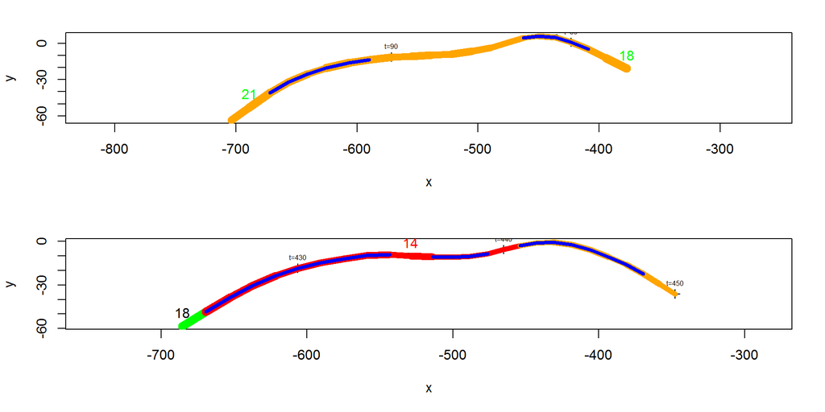

```r
   par(mfrow=c(2,1))
# t1.0 <- 45; t1.n <- 105
# t2.0 <- 400; t2.n <- 485
t1.0 <- 77; t1.n <- 98
t2.0 <- 425; t2.n <- 450
plotTrip       (trip,  tmin=t1.0, tmax=t1.n, header=F, t.mark=10)
plotTripOverlay(trip, curves, tmin=t1.0, tmax=t1.n)
plotTripOverlay(trip, turns, tmin=t1.0, tmax=t1.n, lwd=6, col="magenta")
plotTrip.stopOverlay(trip, stops, tmin=t1.0, tmax=t1.n)
plotTrip       (trip, tmin=t2.0, tmax=t2.n, header=F, t.mark=10)
plotTripOverlay(trip, curves, tmin=t2.0, tmax=t2.n)
```

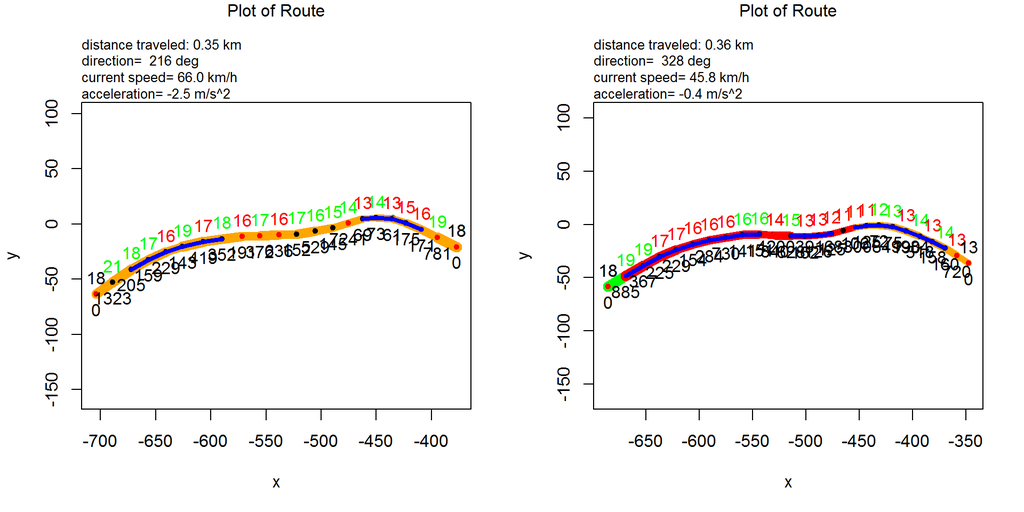

```r
plotTripOverlay(trip, turns, tmin=t2.0, tmax=t2.n, lwd=6, col="magenta")
plotTrip.stopOverlay(trip, stops, tmin=t2.0, tmax=t2.n)

   par(mfrow=c(1,2))
plotTrip.r       (trip,  tmin=t1.0, tmax=t1.n)
plotTripOverlay(trip, curves, tmin=t1.0, tmax=t1.n)
plotTrip.r       (trip, tmin=t2.0, tmax=t2.n)
plotTripOverlay(trip, curves, tmin=t2.0, tmax=t2.n)
```

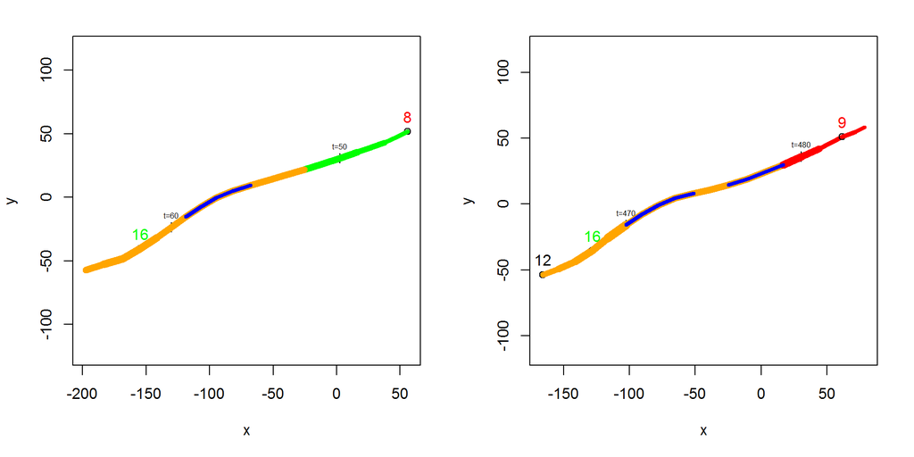

```r
t1.0 <- 45; t1.n <- 65
t2.0 <- 465; t2.n <- 485
plotTrip       (trip,  tmin=t1.0, tmax=t1.n, header=F, t.mark=10)
plotTripOverlay(trip, curves, tmin=t1.0, tmax=t1.n)
plotTripOverlay(trip, turns, tmin=t1.0, tmax=t1.n, lwd=6, col="magenta")
plotTrip.stopOverlay(trip, stops, tmin=t1.0, tmax=t1.n)

plotTrip       (trip, tmin=t2.0, tmax=t2.n, header=F, t.mark=10)
plotTripOverlay(trip, curves, tmin=t2.0, tmax=t2.n)
```

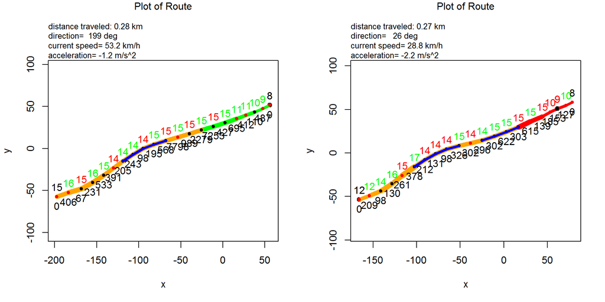

```r
plotTripOverlay(trip, turns, tmin=t2.0, tmax=t2.n, lwd=6, col="magenta")
plotTrip.stopOverlay(trip, stops, tmin=t2.0, tmax=t2.n)

plotTrip.r       (trip,  tmin=t1.0, tmax=t1.n)
plotTripOverlay(trip, curves, tmin=t1.0, tmax=t1.n)
plotTrip.r       (trip, tmin=t2.0, tmax=t2.n)
plotTripOverlay(trip, curves, tmin=t2.0, tmax=t2.n)
```

After all this, I’ve come to the conclusion I’ll be better able to match up trip segments if we go with a tighter radius threshold. 300m looks like a better choice and is plotted below:

(plotted in the conclusion)

This looks better generally, but there is still a discrepancy, if we zoom in on it, we notice that each direction results in a different segment identified as a curve. I’ve extracted just this zoomed section, and plotted them on top of each other, and we see that there is just enough variance in the route to justify the results, but cast doubt on the ability to accurately piece together segments.

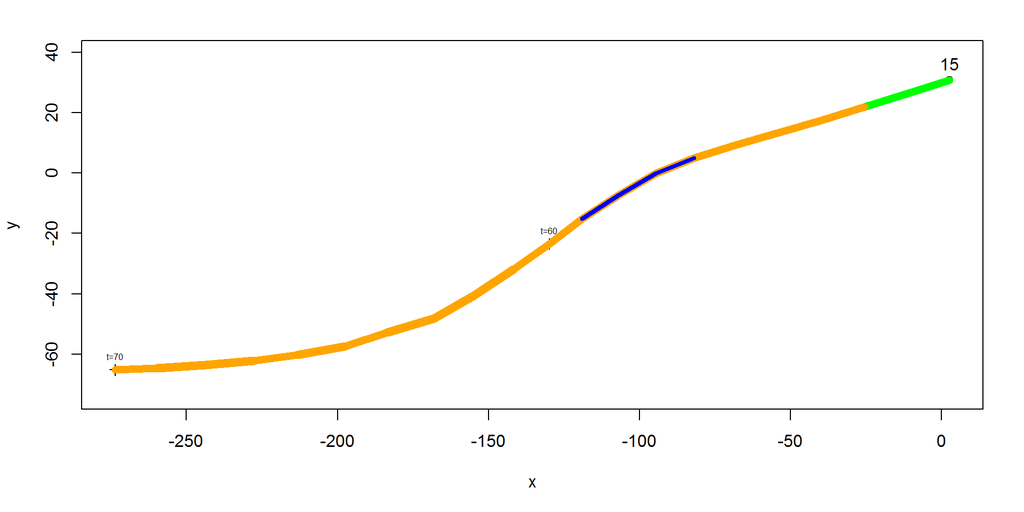

```r
trip.seg <- segment.by.stops(trip)
trip.seg <- segment.by.turns( trip, trip.seg)
trip.seg <- segment.by.curve.gen( trip, trip.seg, r.thresh=300, t.thresh=4, ctype="curve")
segs <- trip.seg[!grepl("^x", trip.seg$type), ]
segs <- segs[ order(segs$t0),]
curves <- segs[grepl("curve",segs$type), ]

t1.0 <- 50; t1.n <- 70
t2.0 <- 460; t2.n <- 480
plotTrip       (trip,  tmin=t1.0, tmax=t1.n, header=F, t.mark=10)
plotTripOverlay(trip, curves, tmin=t1.0, tmax=t1.n)
```

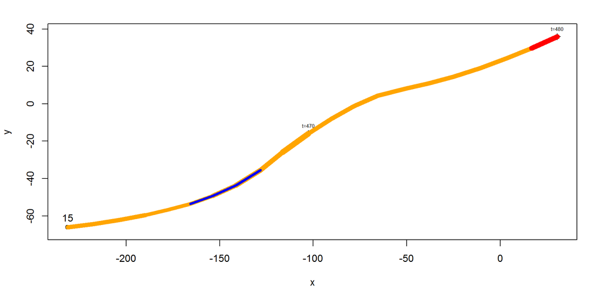

```r
plotTripOverlay(trip, turns, tmin=t1.0, tmax=t1.n, lwd=6, col="magenta")
plotTrip.stopOverlay(trip, stops, tmin=t1.0, tmax=t1.n)

plotTrip       (trip, tmin=t2.0, tmax=t2.n, header=F, t.mark=10)
plotTripOverlay(trip, curves, tmin=t2.0, tmax=t2.n)
```

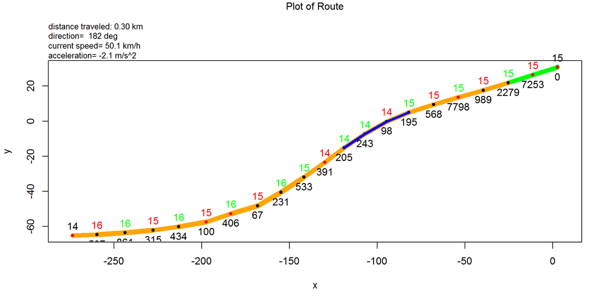

```r
plotTripOverlay(trip, turns, tmin=t2.0, tmax=t2.n, lwd=6, col="magenta")
plotTrip.stopOverlay(trip, stops, tmin=t2.0, tmax=t2.n)

plotTrip.r       (trip,  tmin=t1.0, tmax=t1.n)
plotTripOverlay(trip, curves, tmin=t1.0, tmax=t1.n)
```

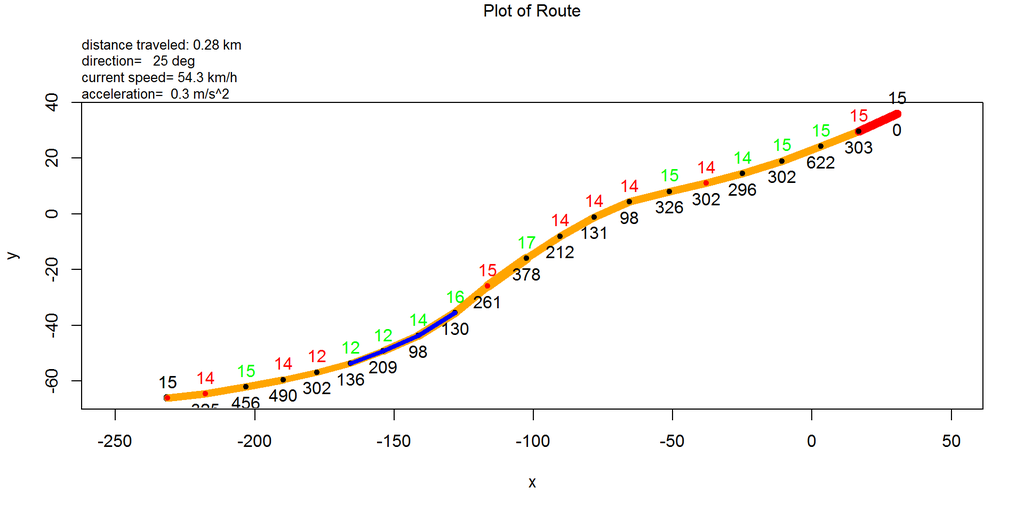

```r
plotTrip.r       (trip, tmin=t2.0, tmax=t2.n)
plotTripOverlay(trip, curves, tmin=t2.0, tmax=t2.n)
```

```r
   par(par.orig)
```

## Conclusion

We’ll have difficulty using the turns and curves to replicate identical trips and reverse trips because there is just enough variance in the data (there appears to be a smoothing algorythm in the data collection that masks this).

We’ll still benefit by carving out curves, and it looks like the thresholds of r=300 and t=4 are reasonable. The curves (blue), turns (magenta) and stops (diamonds) are plotted below. Everything is recalculated from scratch here for completeness

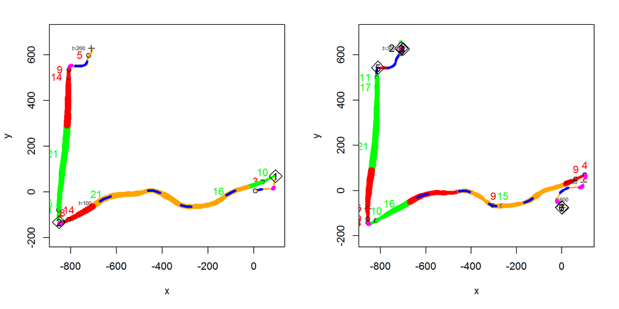

```r
driver.id <- 2591
trip.id <- 49
trip <- getTrip( driver.id, trip.id )

trip.seg <- segment.by.stops(trip)
trip.seg <- segment.by.turns( trip, trip.seg)
trip.seg <- segment.by.curve.gen( trip, trip.seg, r.thresh=300, t.thresh=4, ctype="curve")
segs <- trip.seg[!grepl("^x", trip.seg$type), ]
segs <- segs[ order(segs$t0),]
curves <- segs[grepl("curve",segs$type), ]
turns <- segs[grepl("turn",segs$type), ]
stops <- segs[grepl("stop",segs$type), ]

   par(mfrow=c(1,2))
plotTrip       (trip,         tmax=200, header=F)
plotTripOverlay(trip, curves, tmax=200)
plotTripOverlay(trip, turns, tmax=200, lwd=6, col="magenta")
plotTrip.stopOverlay(trip, stops, tmax=200)

plotTrip       (trip,         tmin=200, header=F)
plotTripOverlay(trip, curves, tmin=200)
plotTripOverlay(trip, turns, tmin=200, lwd=6, col="magenta")
plotTrip.stopOverlay(trip, stops, tmin=200)
```

```r
   par(par.orig)
```

And for grins, here’s another trip (99)

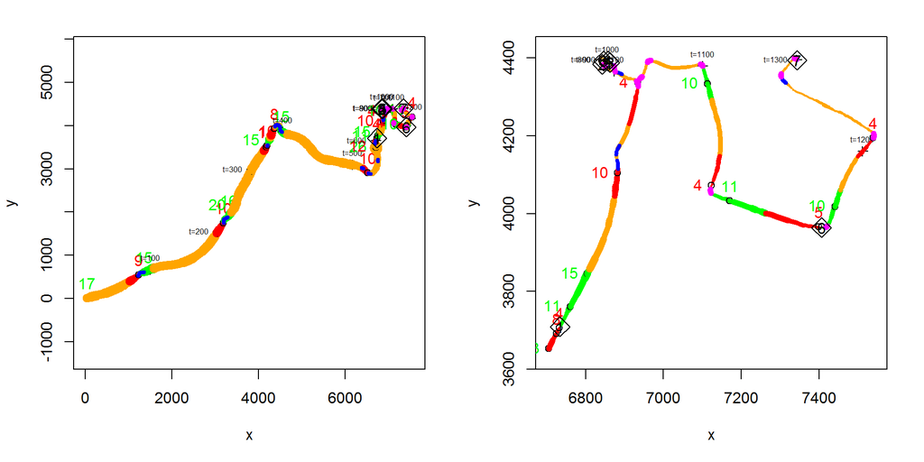

```r
driver.id <- 2591
trip.id <- 99
trip <- getTrip( driver.id, trip.id )
trip.seg <- segment.by.stops(trip)
trip.seg <- segment.by.turns( trip, trip.seg)
trip.seg <- segment.by.curve.gen( trip, trip.seg, r.thresh=300, t.thresh=4, ctype="curve")
segs <- trip.seg[!grepl("^x", trip.seg$type), ]
segs <- segs[ order(segs$t0),]
curves <- segs[grepl("curve",segs$type), ]
turns <- segs[grepl("turn",segs$type), ]
stops <- segs[grepl("stop",segs$type), ]

  par(mfrow=c(1,2))
plotTrip       (trip,          header=F)
plotTripOverlay(trip, curves)
plotTripOverlay(trip, turns, lwd=6, col="magenta")
plotTrip.stopOverlay(trip, stops)

plotTrip       (trip, tmin=600,         header=F)
plotTripOverlay(trip, tmin=600, curves)
plotTripOverlay(trip, tmin=600, turns, lwd=6, col="magenta")
plotTrip.stopOverlay(trip, stops)
```

```r
  par( par.orig )
```

## Functions created/used

```r
segment.by.curve.gen
```

```
## function (trip, trip.seg, r.thresh = 20, t.thresh = 2, ctype = "gen.curve")
## {
##     segs.unk <- trip.seg[is.na(trip.seg$type), ]
##     for (seg in segs.unk$id) {
##         seg.data <- segs.unk[segs.unk$id == seg, ]
##         t.beg <- seg.data$t0
##         t.fin <- seg.data$tn
##         turns <- with(seg.data, segment.parse.curve.gen(trip,
##             tmin = t.beg, tmax = t.fin, r.thresh = r.thresh,
##             t.thresh = t.thresh))
##         if (nrow(turns) > 0) {
##             t <- t.beg
##             i.seg <- nrow(trip.seg)
##             for (i in 1:nrow(turns)) {
##                 t0 <- turns[i, "t0"]
##                 tn <- turns[i, "tn"]
##                 if (t0 > t) {
##                   i.seg <- i.seg + 1
##                   trip.seg <- rbind(trip.seg, data.frame(id = i.seg,
##                     t0 = t, tn = t0 - 1, type = NA, type.id = NA))
##                 }
##                 i.seg <- i.seg + 1
##                 trip.seg <- rbind(trip.seg, data.frame(id = i.seg,
##                   t0 = t0, tn = tn, type = ctype, type.id = i +
##                     (1000 * seg)))
##                 t <- tn + 1
##             }
##             if (t <= t.fin) {
##                 i.seg <- i.seg + 1
##                 trip.seg <- rbind(trip.seg, data.frame(id = i.seg,
##                   t0 = t, tn = t.fin, type = NA, type.id = NA))
##             }
##             trip.seg[trip.seg$id == seg, "type"] <- "x.split"
##             turns$id <- 1:nrow(turns) + seg * 1000
##             if (exists("trip.turns")) {
##                 trip.turns <- rbind(trip.turns, turns)
##             }
##             else {
##                 trip.turns <- turns
##             }
##         }
##     }
##     segment.clean.points(trip.seg)
## }
```

```r
plotTripOverlay
```

```
## function (trip, segs, col = "blue", lwd = 4, tmin = 1, tmax = nrow(trip))
## {
##     tmin <- max(tmin, 1)
##     tmax <- min(tmax, nrow(trip))
##     for (i in 1:nrow(segs)) {
##         t0 <- segs[i, "t0"]
##         tn <- segs[i, "tn"]
##         if (t0 < tmin | tn > tmax)
##             next
##         i.col <- ifelse("col" %in% colnames(segs), segs[i, "col"],
##             col)
##         i.lwd <- ifelse("lwd" %in% colnames(segs), segs[i, "lwd"],
##             lwd)
##         if (t0 == tn)
##             next
##         for (t in t0:(tn - 1)) {
##             lines(trip[t:(t + 1), "x"], trip[t:(t + 1), "y"],
##                 col = i.col, lwd = i.lwd)
##         }
##     }
## }
```